# BCB420-Assignment 2

Yuewei Wang

2022-03-14

# 1. Brief Introduction of Assignment 1 Results

### Load the needed packages:

```r
if (!require("BiocManager", quietly = TRUE))
  install.packages("BiocManager")

if (!requireNamespace("GEOmetadb", quietly = TRUE)){
  BiocManager::install("GEOmetadb")
}
if (!require("knitr", quietly = TRUE))
  install.packages("knitr")

if (! requireNamespace("edgeR", quietly = TRUE)) {
    BiocManager::install("edgeR")
}

library(GEOmetadb)
library(knitr)
library(edgeR)
```

### Loading the chosen dataset:

- The choice of dataset is *GSE85995*, the data file was download by using GEOmetadb package method.
- In assignment 1, clean process was performed to remove **duplicated**, **non-informative** and **weakly express** data. Mapping process was performed by mappping row identifiers into the most updated HGNC symbols. The cleaned and mapped data was saved into *gata3_cleaned_mapped_data.rds* file. More detail code algorithm was presented in *A1.Rmd* file.

```r
sfiles = getGEOSuppFiles('GSE85995')

# <clean and map, the detailed code are in "A1.Rmd"> ...

if (!file.exists("gata3_cleaned_mapped_data.rds")) {
  options(knitr.duplicate.label = 'allow')
  source(purl("A1.Rmd", output = tempfile()))
}
gata3_cleaned_maped_data <- readRDS("gata3_cleaned_mapped_data.rds")
```

- **TMM** normalization was performed in assignment 1.

```r
filtered_data_matrix <- as.matrix(gata3_cleaned_maped_data[,3:ncol(gata3_cleaned_maped_data)])
rownames(filtered_data_matrix) <- gata3_cleaned_maped_data$hgnc_symbols
group = c(rep("scrambled siRNA",3),rep("GATA3 siRNA",3))
d = DGEList(counts=filtered_data_matrix, group = group)
d = calcNormFactors(d)
normalized_cleaned_gata3 <- cpm(d)
```

- Density plots were compared for the cleaned and mapped data before and after normalization. The data before normalization followed a normal distribution. After normalization, the pattern remained and the edges of the data were cleaned up slightly.

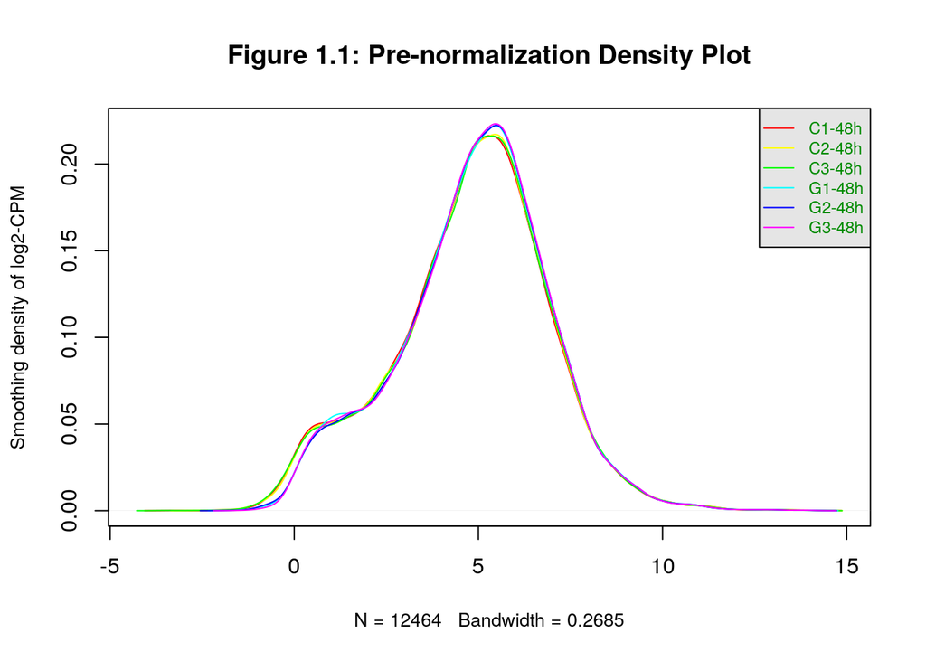

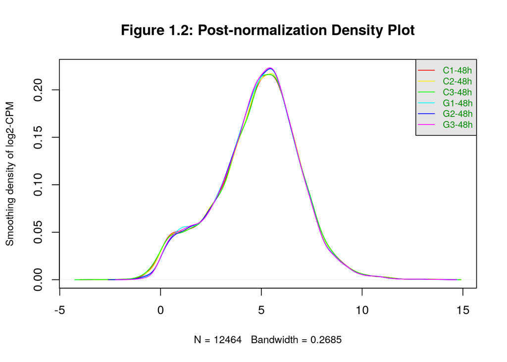

Figure 1: GATA3 RNASeq Samples Density Plots Comparison by using TMM Normalization.

```r
# before
data2plot <- log2(cpm(gata3_cleaned_maped_data[,3:ncol(gata3_cleaned_maped_data)]))
counts_density <- apply(data2plot, 2, density)
xlim <- 0; ylim <- 0
for (i in 1:length(counts_density)) {
  xlim <- range(c(xlim, counts_density[[i]]$x));
  ylim <- range(c(ylim, counts_density[[i]]$y))
}
cols <- rainbow(length(counts_density))
ltys <- rep(1, length(counts_density))
plot(counts_density[[1]], xlim=xlim, ylim=ylim, type="n",
     ylab="Smoothing density of log2-CPM",
     main = "Figure 1.1: Pre-normalization Density Plot",
     cex.lab = 0.85)
for (i in 1:length(counts_density)) lines(counts_density[[i]], col=cols[i], lty=ltys[i])
legend("topright", colnames(data2plot),
       col=cols, lty=ltys, cex=0.75,
       border ="blue",  text.col = "green4",
       merge = TRUE, bg = "gray90")

# after
normalized_data2plot <- log2(normalized_cleaned_gata3)
normalized_counts_density <- apply(normalized_data2plot, 2, density)
xlim <- 0; ylim <- 0
for (i in 1:length(normalized_counts_density)) {
  xlim <- range(c(xlim, normalized_counts_density[[i]]$x));
  ylim <- range(c(ylim, normalized_counts_density[[i]]$y))
}
cols <- rainbow(length(normalized_counts_density))
ltys <- rep(1, length(normalized_counts_density))
plot(normalized_counts_density[[1]], xlim=xlim, ylim=ylim, type="n",
     ylab="Smoothing density of log2-CPM",
     main = "Figure 1.2: Post-normalization Density Plot",
     cex.lab = 0.85)
for (i in 1:length(normalized_counts_density)) lines(normalized_counts_density[[i]], col=cols[i], lty=ltys[i])
legend("topright", colnames(normalized_data2plot),
       col=cols, lty=ltys, cex=0.75,
       border ="blue",  text.col = "green4",
       merge = TRUE, bg = "gray90")
```

- The normalized data was saved into *gata3_cleaned_normalized.rds* file.

```r
if (!file.exists("gata3_cleaned_normalized.rds")) {
  saveRDS(normalized_cleaned_gata3, "gata3_cleaned_normalized.rds")
}
```

# 2. Load Data

### Load packages used in assignment 2:

```r
if (!requireNamespace("ComplexHeatmap", quietly = TRUE)){
  BiocManager::install("ComplexHeatmap")
}
if (!require("kableExtra", quietly = TRUE))
  install.packages("kableExtra")
library(ComplexHeatmap)
library(circlize)
library(kableExtra)
```

### Load the saved data from assignment 1:

- Load the saved data and construct the sample matrix for further differential gene expression process. The control condition was marked as *C* and the testing condition was marked as *G*.

```r
if (!file.exists("gata3_cleaned_normalized.rds")) {
  options(knitr.duplicate.label = 'allow')
  source(purl("A1.Rmd", output = tempfile()))
}
gata3_data <- readRDS("gata3_cleaned_normalized.rds")
gata3_samples<-data.frame(lapply(colnames(gata3_data),
                                 FUN=function(x){unlist(strsplit(x, split = "-")[[1]][1])}))
gata3_samples<-data.frame(lapply(gata3_samples[1,],
                                 FUN=function(x){unlist(strsplit(x, split = ""))}))
colnames(gata3_samples) <- data.frame(lapply(colnames(gata3_data),
                                 FUN=function(x){unlist(strsplit(x, split = "-")[[1]][1])}))
rownames(gata3_samples) <- c("cell_type","sample_type")
gata3_samples <- data.frame(t(gata3_samples))
gata3_samples
```

```
##    cell_type sample_type
## C1         C           1
## C2         C           2
## C3         C           3
## G1         G           1
## G2         G           2
## G3         G           3
```

```r
colnames(gata3_data) <- rownames(gata3_samples)
head(gata3_data)
```

```
##                 C1        C2        C3        G1        G2        G3
## TSPAN6    20.34736  19.09082  19.83265  18.91879  19.25711  17.84209
## DPM1      95.60966 107.10127  91.66746  92.90582  98.28257  95.75189
## SCYL3     10.98069  11.24841  10.24895  11.03344  10.97703  10.84601
## C1orf112  23.33656  24.44822  23.71642  20.81125  22.50419  25.58163
## CFH       33.78743  34.38800  37.53056  33.85532  32.21453  32.63726
## FUCA2    115.00682 118.33976 119.85482 106.58556 110.16967 108.24744
```

# 3. Differential Gene Expression

### Code inplementation:

- We will visualize the normalized data by applying them to a heat map initially.

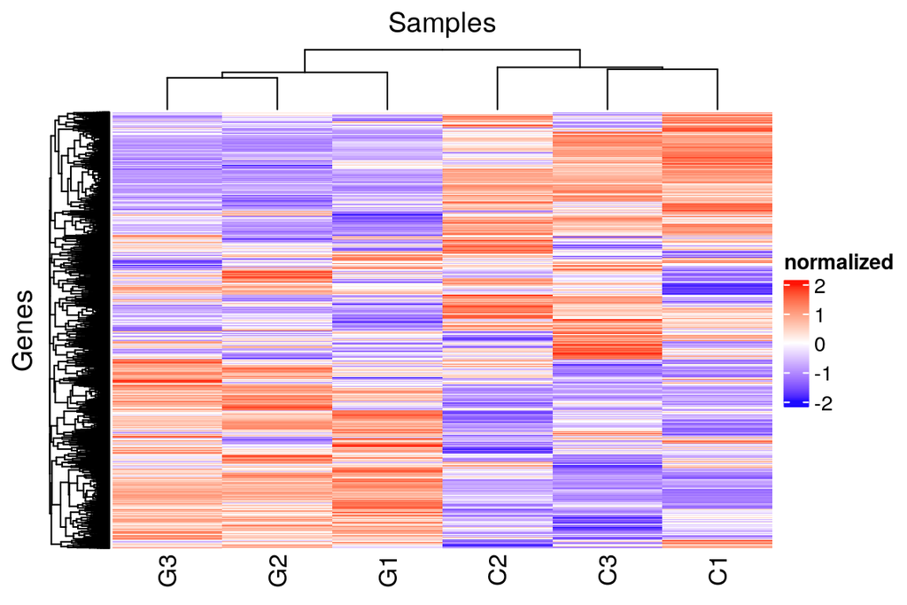

```r
# scale and center data
heatmap_matrix <- t(scale(t(gata3_data)))

if(min(heatmap_matrix) == 0){
  heatmap_col = colorRamp2(c( 0, max(heatmap_matrix)),
                           c( "white", "red"))
} else {
  heatmap_col = colorRamp2(c(min(heatmap_matrix), 0, max(heatmap_matrix)),
                           c("blue", "white", "red"))
}
current_heatmap <- Heatmap((heatmap_matrix),
                           show_row_dend = TRUE,show_column_dend = TRUE,
                           col=heatmap_col,show_column_names = TRUE,
                           show_row_names = FALSE,show_heatmap_legend = TRUE,
                           column_title = "Samples",
                           row_title = "Genes",
                           name = "normalized")
current_heatmap
```

- Revisit the MDS plot from Assignment 1 (regarding cell type difference), and introduce a new model for different sample type.

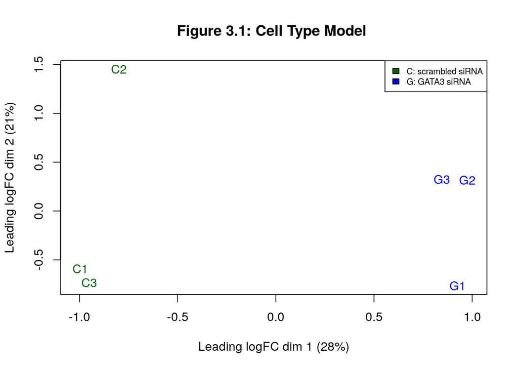

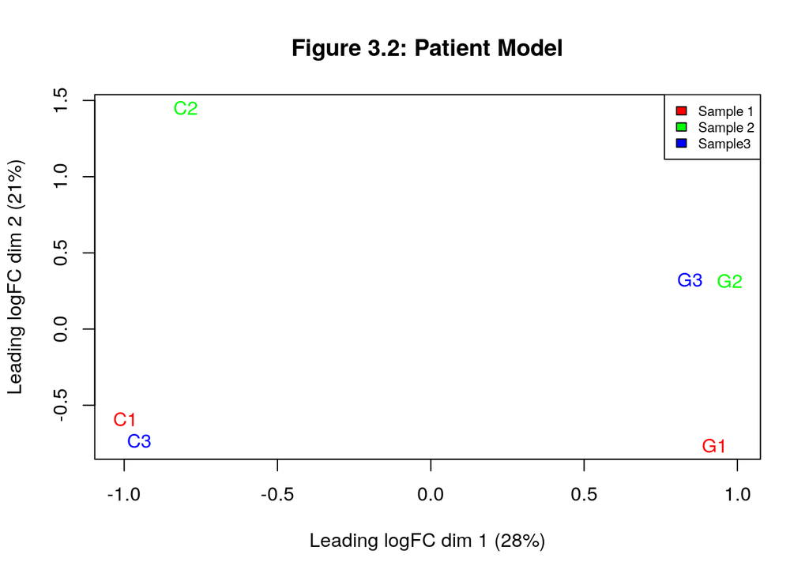

Figure 3: GATA3 RNASeq Samples MDS Plots Comparison by using Two Models

```
 According to the MDS plots, the distance of clustering grouped by cell typle is more close to grouped by patients.
```

```r
# MDS plot, by cell type (in A1)
plotMDS(heatmap_matrix,
        col = c("darkgreen", "blue")[factor(gata3_samples$cell_type)],
        main = "Figure 3.1: Cell Type Model ")
legend("topright",
       legend=c("C: scrambled siRNA", "G: GATA3 siRNA"),
       fill = c("darkgreen", "blue"),
       cex=0.7)

# MDS plot by sample cluster
pat_colors <- unlist(rainbow(3))[factor(gata3_samples$sample_type)]
plotMDS(heatmap_matrix,
        col = pat_colors,
        main = "Figure 3.2: Patient Model")
legend("topright",
       legend=c("Sample 1", "Sample 2", "Sample3"),
       fill = pat_colors,
       cex=0.7)
```

- Construct the models (**Simple model** and **Complex model**) and perform **Limma** analysis.

```r
# cell type variation model
cell_type_model <- model.matrix(~ gata3_samples$cell_type)
kable(cell_type_model, type="html")
expressionMatrix <- as.matrix(gata3_data)
rownames(expressionMatrix) <- rownames(gata3_data)
colnames(expressionMatrix) <- colnames(gata3_data)
minimalSet <- ExpressionSet(assayData=expressionMatrix)
fit <- lmFit(minimalSet, cell_type_model)
fit2 <- eBayes(fit,trend=TRUE)
topfit <- topTable(fit2,
                   coef=ncol(cell_type_model),
                   adjust.method = "BH",
                   number = nrow(expressionMatrix))
output_hits <- merge(rownames(gata3_data),
                     topfit,
                     by.y=0,by.x=1,
                     all.y=TRUE)
colnames(output_hits)[1] <- "hgnc_symbol"
output_hits <- output_hits[order(output_hits$P.Value),]
kable(output_hits[1:3,],type="html",row.names = FALSE)

# patient + cell type model
patient_model <- model.matrix(~ gata3_samples$sample_type +
                                gata3_samples$cell_type)
kable(patient_model,type="html")
fit_patient <- lmFit(minimalSet, patient_model)
fit_patient2 <- eBayes(fit_patient,trend=TRUE)
topfit_pat <- topTable(fit_patient2,
                   coef=ncol(patient_model),
                   adjust.method = "BH",
                   number = nrow(expressionMatrix))
output_sample_type_hits <- merge(rownames(gata3_data),
                                 topfit_pat,
                                 by.y=0,by.x=1,
                                 all.y=TRUE)
colnames(output_sample_type_hits)[1] <- "hgnc_symbol"
output_sample_type_hits <- output_sample_type_hits[order(output_sample_type_hits$P.Value),]
kable(output_sample_type_hits[1:3,],type="html",row.names = FALSE)
```

[output not shown]